# Auto Accidents Toronto: Case Study

Mark Edney

2021-08-09

## Introduction

This is a custom case study for the Capstone Project for the Google Data Analytics course on Coursera. This case study outlines the steps to create and solve a bussiness using a dataset.

## Ask

The business task is to research into traffic collisions for a tow trucking company in Toronto. Where should tow trucks be stationed to most quickly respond to calls in the most common collision sites? What are the best times to have employees working? Are there times in the year would it would be a good idea to hire contractors to meet increased demand?

The main stakeholders are the owners of the tow truck company requesting data analysis. An additional stakeholder is the police department as the are the owners of the dataset.

The database is the automotive traffic collisions dataset for Toronto from the open data Toronto site found [here](https://open.toronto.ca/dataset/police-annual-statistical-report-traffic-collisions/).

## Prepare

The following short script is used to download the automotive accident data from the open data Toronto database. The data is than saved as an RDS file. RDS files are unique to R studio, which is a major disadvantage, but compress the data significantly more than a csv file.

```r
library(opendatatoronto)
library(tidyverse)
library(lubridate)

auto.data <- show_package("ec53f7b2-769b-4914-91fe-a37ee27a90b3") %>%
        list_package_resources() %>%
        get_resource() %>%
        as_tibble()
saveRDS(auto.data, "Auto_accidents_toronto.RDS")
auto.data <- readRDS("Auto_accidents_toronto.RDS")
```

The best way to observe the data is with the ‘glimpse’ function, which clearly outlines the structure of the data.

```r
glimpse(auto.data)
```

```
## Rows: 415,918
## Columns: 18
## $ OBJECTID          <int> 126, 127, 128, 129, 130, 131, 132, 133, 134, 135, 13~
## $ EventUniqueId     <chr> "GO-20141274487", "GO-20141274697", "GO-20141274712"~
## $ OccurrenceDate    <dttm> 2014-01-03, 2014-01-03, 2014-01-03, 2014-01-03, 201~
## $ Month             <chr> "January", "January", "January", "January", "January~
## $ Day_of_Week       <chr> "Friday", "Friday", "Friday", "Friday", "Friday", "F~
## $ Year              <int> 2014, 2014, 2014, 2014, 2014, 2014, 2014, 2014, 2014~
## $ Hour              <int> 14, 15, 15, 15, 16, 16, 16, 17, 9, 17, 17, 18, 18, 1~
## $ Division          <chr> "D51", "D54/D55", "D12", "D22", "D33", "D52", "D51",~
## $ Atom              <chr> "73", "68", "30", "17", "42", "76", "75", "26", "116~
## $ Neighbourhood     <chr> "Moss Park (73)", "North Riverdale (68)", "Brookhave~
## $ Fatalities        <int> 0, 0, 0, 0, 0, 0, 0, 0, 0, 0, 0, 0, 0, 0, 0, 0, 0, 0~
## $ Injury_Collisions <chr> "NO", "YES", "NO", "NO", "YES", "YES", "NO", "YES", ~
## $ FTR_Collisions    <chr> "NO", "NO", "NO", "NO", "NO", "NO", "NO", "NO", "NO"~
## $ PD_Collisions     <chr> "YES", "NO", "YES", "YES", "NO", "NO", "YES", "NO", ~
## $ Longitude         <dbl> -79.36270, -79.34516, -79.47870, -79.51129, -79.3388~
## $ Latitude          <dbl> 43.65408, 43.66709, 43.70172, 43.61839, 43.72050, 43~
## $ ObjectId2         <int> 1, 2, 3, 4, 5, 6, 7, 8, 9, 10, 11, 12, 13, 14, 15, 1~
## $ geometry          <POINT [°]> POINT (-79.3627 43.65408), POINT (-79.34516 43~
```

## Process

Some errors are observed from the data import. Some of the columns can be dropped as they don’t add anything to the analysis.

```r
auto.data <- auto.data %>%
  select(-c(OBJECTID, EventUniqueId, Division, Atom, ObjectId2, geometry))
```

Some of the column names are not very descriptive such as FTR_Collisions and PD_Collisions. From the metadata descriptions, these values represent “Failure to remain at the scene” and “Property Damage” respectively.

```r
auto.data <- auto.data %>%
  rename("Left_scene" = FTR_Collisions, "Property_Damage" = PD_Collisions, "Injury" = Injury_Collisions)
```

The last three columns also only have yes/no possible values so they are better represented as factors.

```r
auto.data <- auto.data %>%
  mutate(Left_scene = as.factor(Left_scene), Property_Damage = as.factor(Property_Damage),
            Injury = as.factor(Injury),
         Day_of_Week = factor(Day_of_Week, levels = c("Monday", "Tuesday", "Wednesday", "Thursday",
"Friday", "Saturday", "Sunday")))
```

## Analyze

### Neighbourhoods

The first step it to identify the neighborhoods with the highest rate of collisions. The neighborhood is used rather than the GPS coordinates as it greatly reduces the results into manageable areas.

```r
Location <- auto.data %>%
  count(Neighbourhood) %>%
  arrange(-n)
```

The top 10 Neighborhoods for collisions can than be plotted:

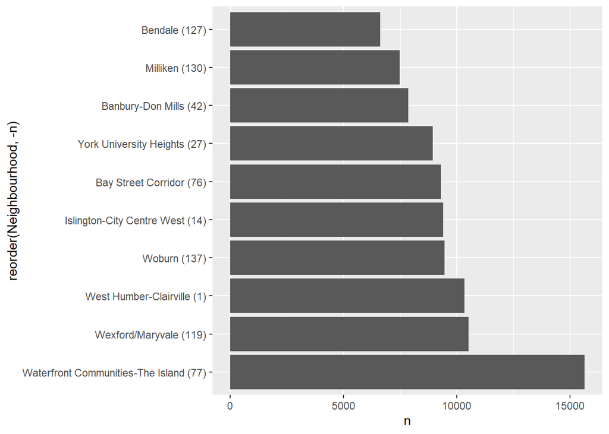

```r
ggplot(Location[1:10,], aes(y = n, x = reorder(Neighbourhood, -n))) +
  geom_bar(stat = "identity") +
  coord_flip()
```

With the neighborhoods with the greatest collision response identified, it may be useful to map them. There are many different way to find the neighborhoods, there may even be shape files outlining the neighborhoods borders, but the easiest way would to simple find the average of the Latitude and Longitude values when grouped by neighborhood. This dataframe can than be join with the previous summary to add the count values.

```r
Area <- auto.data %>%
  group_by(Neighbourhood) %>%
  summarise(Longitude = mean(Longitude), Latitude = mean(Latitude)) %>%
  left_join(Location)
```

### Dates

Trends for the date can be observed from a plot of the days of the week against the count. Any trend with the hour of the day can also be observed on the same chart.

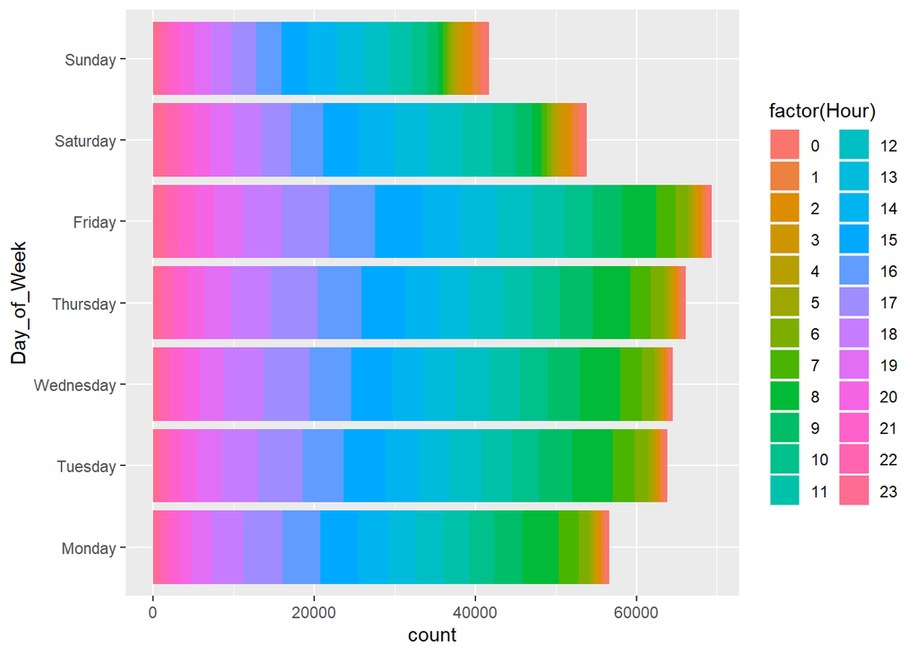

```r
auto.data %>%
  ggplot(aes(x = Day_of_Week, fill = factor(Hour))) +
  geom_bar() +
  coord_flip()
```

There is no clear trend with the previous plot as there are to many possible times in the date. The time of day should be observed separately.

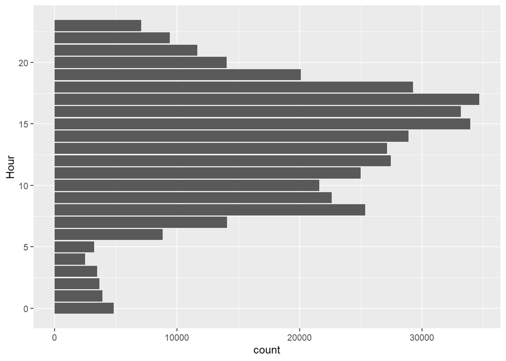

```r
auto.data %>%
  ggplot(aes(x = Hour)) +
  geom_bar() +
  coord_flip()
```

Finding the frequency of collisions by month would show any seasonal variation such as the commonly accepted theory of increased collisions during snowy months.

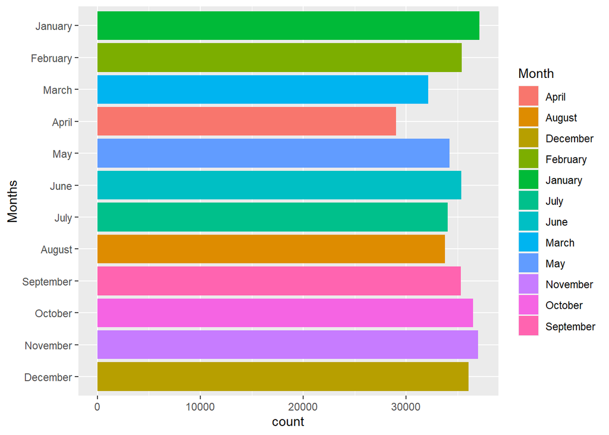

```r
auto.data %>%
  ggplot(aes(x = reorder(Month, -month(OccurrenceDate)), fill = Month)) +
  geom_bar() +
  labs(x="Months") +
  coord_flip()
```

### Chance of injuries

The last thing to look at is the probability for each of the factors within the data.

```r
mean(auto.data$Injury=="YES")*100
```

```
## [1] 14.56249
```

```r
mean(auto.data$Left_scene=="YES")*100
```

```
## [1] 17.20988
```

```r
mean(auto.data$Property_Damage=="YES")*100
```

```
## [1] 70.65143
```

## Share

The Visual for the case study are included in the Analyze stage of this report but also include the following tableau dashboard found [here](https://public.tableau.com/app/profile/mark.edney/viz/Collisions_Toronto_CS/Dashboard1).

## Act

From the analyze provide in this report, and the visuals to support it, it is clear that the best advice for the client would be to focus on the regions with the highest collisions such as the waterfront communities. It is also clear that collisions most often occur during the week ramping up to Friday. It would be best to operate between the hours of 8 am to 7 pm. There doesn’t seem to be any seasonal variation so there is no need to contract employees for the winter season. There is a small chance of injury for each collision but it maybe a good idea for each tow truck driver to complete some first aid training.

Going further, I would look into locations that have access to highways as that would enable tow truck drivers easier access to a large area of accidents. With that in mind it maybe beneficial to include the average speed limit for each neighborhood.